# Phylogenetic tree calibration

Silvia Castiglione, Carmela Serio, Pasquale Raia

## scaleTree tool

The function `scaleTree` is a useful tool to deal with phylogenetic age calibration written around Gene Hunt’s scalePhylo function (http://paleobiology.si.edu/staff/individuals/hunt.cfm). It rescales branches and leaves of the tree according to species and/or nodes calibration ages (meant as distance from the youngest tip within the tree).

If only species ages are supplied (argument `tip.ages`), the function changes leaves length, leaving node ages and internal branch lengths unaltered. When node ages are supplied (argument `node.ages`), the function shifts nodes position along their own branches while keeping other nodes and species positions unchanged.

```r
sp.ages
```

```
#>    t9   t73   t11   t43   t78   t46   t52   t26
#> 1.250 1.205 0.000 2.430 3.150 1.050 0.000 1.550
```

```r
scaleTree(tree,tip.ages=sp.ages)->treeS1
nod.ages
```

```
#>   98  152  123   85  118  127  164  143
#> 10.7  0.7  1.2 12.6  5.1  5.8 18.8 12.8
```

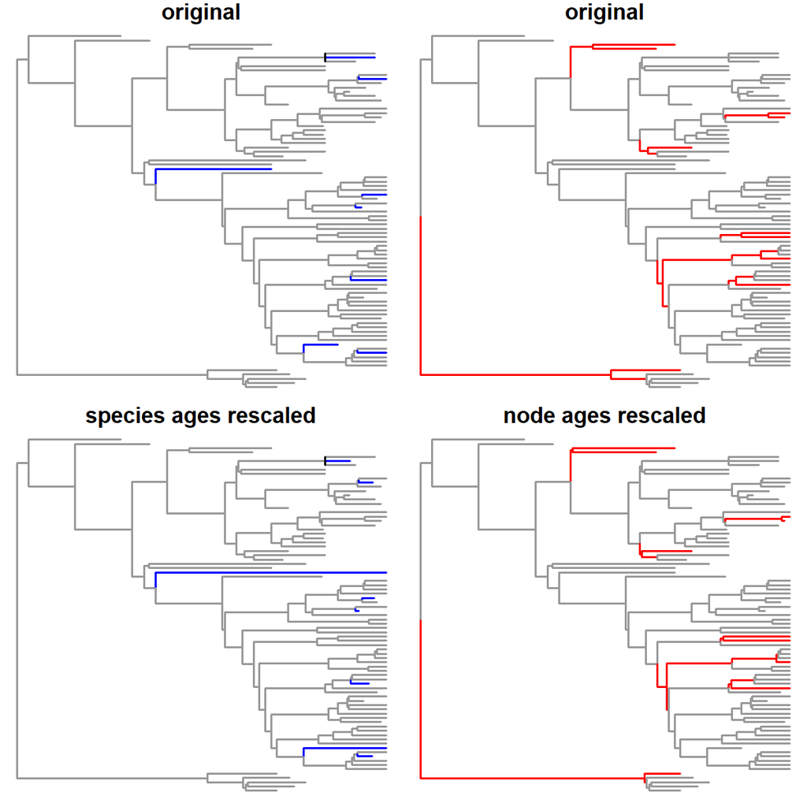

```r
scaleTree(tree,node.ages=nod.ages)->treeS2
```

It may happen that species and/or node ages to be calibrated are older than the age of their ancestors. In such cases, after moving the species (node) to its target age, the function reassembles the phylogeny above it by assigning the same branch length (set through the argument `min.branch`) to the all the branches along the species (node) path, so that the tree is well-conformed and ancestor-descendants relationships remain unchanged. In this way changes to the original tree topology only pertain to the path along the “calibrated” species.

```r
c(sp.ages,nod.ages)
```

```
#>   t1   96
#> 20.5 15.6
```

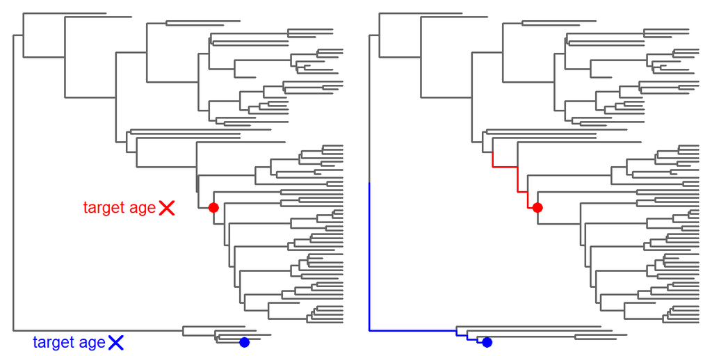

```r
scaleTree(tree,tip.ages = sp.ages,node.ages = nod.ages,min.branch = 1)->treeS
```